# IODS course project

## 3) Personal hypothesis of relationships with high/low alcohol use and 4 variables

I am choosing my prediction variables as goout, studytime, absences and higher.

My personal hypothesis is that going out (goout) and having absences at school affect high_use positively, so high numbers imply True High alcohol use.

Studytime and wanting to go to a higher education (higher) affect high_use negatively, so high numbers in studytime and yes in higher imply False in High alcohol use.

## 4) Numerical & graphical exploration of the variable distributions and relationship with high_use

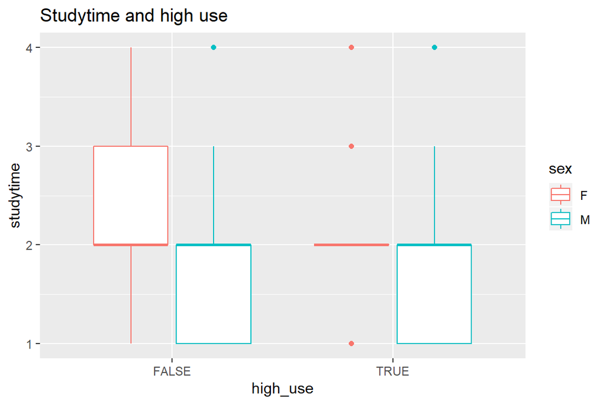

```r
g <- ggplot(data = alc, aes(x = high_use, y = studytime, col = sex))
g  + geom_boxplot() + ggtitle("Studytime and high use")
```

```r
table(alc$high_use, alc$higher)
```

```
##
##          no yes
##   FALSE   9 259
##   TRUE    9 105
```

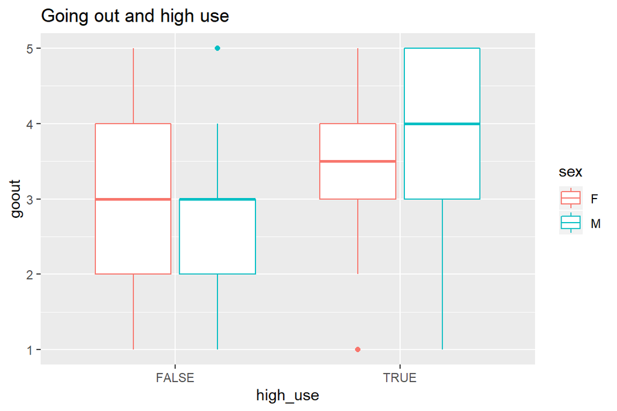

```r
g2 <- ggplot(data = alc, aes(x = high_use, y = goout, col = sex))
g2 + geom_boxplot() + ggtitle("Going out and high use")
```

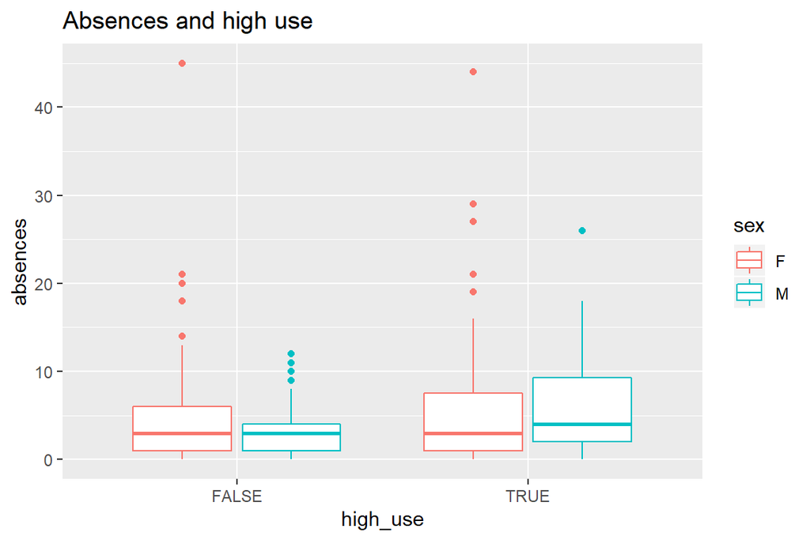

```r
g3 <- ggplot(data = alc, aes(x = high_use, y = absences, col = sex ))
g3 +  geom_boxplot() + ggtitle("Absences and high use")
```

Now let’s look at these boxplots and table.

**Studytime and high use:** Studytime seems to be longer among females, who are not high users. Among males studytime seems to have no relationship with high use.

**Higher education goals and high use:** Those who said they wish to have higher education are more often not high users (over two times). However not wanting a higher education is not connected to high use, and with small n is hard to say anything at all.

**Going out and high use:** Withing both sexes, those who go out more, are more often high users. Within males the distribution are more clearly separated withing high use groups.

**Absences and high use:** There is a small difference between groups, but especially males who are high users have more absences at school. Among females the difference is not as clear.

Overall my hypotheses seem to be okay and in the right direction.

## 5) Fitting the logical regression model

```r
m <- glm(high_use ~ higher + studytime + absences + goout, data = alc, family = "binomial")

summary(m)
```

```
##
## Call:
## glm(formula = high_use ~ higher + studytime + absences + goout,
##     family = "binomial", data = alc)
##
## Deviance Residuals:
##     Min       1Q   Median       3Q      Max
## -1.8320  -0.7910  -0.5207   0.8547   2.5011
##
## Coefficients:
##             Estimate Std. Error z value Pr(>|z|)
## (Intercept) -2.26901    0.72314  -3.138  0.00170 **
## higheryes   -0.23789    0.54474  -0.437  0.66233
## studytime   -0.54886    0.16864  -3.255  0.00114 **
## absences     0.06926    0.02214   3.128  0.00176 **
## goout        0.72431    0.11809   6.134 8.59e-10 ***
## ---
## Signif. codes:  0 '***' 0.001 '**' 0.01 '*' 0.05 '.' 0.1 ' ' 1
##
## (Dispersion parameter for binomial family taken to be 1)
##
##     Null deviance: 465.68  on 381  degrees of freedom
## Residual deviance: 389.95  on 377  degrees of freedom
## AIC: 399.95
##
## Number of Fisher Scoring iterations: 4
```

```r
coef(m)
```

```
## (Intercept)   higheryes   studytime    absences       goout
## -2.26901424 -0.23788711 -0.54885624  0.06926153  0.72430592
```

```r
OR <- coef(m) %>% exp

CI <- confint(m) %>% exp
cbind(OR, CI)
```

```
##                    OR      2.5 %    97.5 %
## (Intercept) 0.1034141 0.02415516 0.4170871
## higheryes   0.7882917 0.26741940 2.3197494
## studytime   0.5776101 0.41056294 0.7968379
## absences    1.0717165 1.02754493 1.1219271
## goout       2.0632985 1.64619553 2.6180962
```

**Looking at the summary:**  
Varibles studytime, absences and gotout have a statistically significant relationship (p < 0.05) with high use. Higher has p.value= 0.66 , thus it could be removed form the model.

Studytime has a negative relationship with high use, so those who study more are less likely to be high users.

Absences and going out have positive relationship with high use, and goout has the strongest effect.

So conserning the coeffidents and p-values, my hypothesis seems to right, except that higher was not a good variable to predict high use.

**Confidence intervals:**  
Higheryes has the widest interval (0.27-2.32), and the confidence interval includes one, which also strongly implies it being a bad predictor variable, since the variable could have both negative and positive effect on high use.

Studytime odds ratio is 0.578, so less than 1, which means it is negatively associated with success, succes being high alcohol user. Absences and goout have odds ratios 1.07 and 2.06, so higher than one, which means they are positively associated with success high use, thus being a high user. This also supports my hypothesis.

## 6) Predictive power of the model

```r
# Let's drop higher out of the model
m2 <- glm(high_use ~ studytime + absences + goout, data = alc, family = "binomial")

probabilities <- predict(m2, type = "response")

alc <- mutate(alc, probability = probabilities)

alc <- mutate(alc, prediction = probability > 0.5)

table(high_use = alc$high_use, prediction = alc$prediction)
```

```
##         prediction
## high_use FALSE TRUE
##    FALSE   246   22
##    TRUE     66   48
```

```r
table(high_use = alc$high_use, prediction = alc$prediction) %>% prop.table() %>% addmargins()
```

```
##         prediction
## high_use      FALSE       TRUE        Sum
##    FALSE 0.64397906 0.05759162 0.70157068
##    TRUE  0.17277487 0.12565445 0.29842932
##    Sum   0.81675393 0.18324607 1.00000000
```

When we look at the cross tabulations, we see that the most False high users are classified as false (so prediction works okay). But then most True high users are predicted as False high users, which implies this prediction model doesnt work all the way we would want.

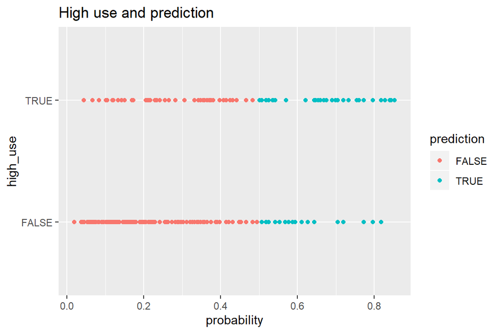

```r
g4 <- ggplot(alc, aes(x = probability, y = high_use, col = prediction))
g4 + geom_point() + ggtitle("High use and prediction")
```

Plotting reveals the same result. Most False high users are rightly predicted as False high users, but most of those whose high_us is true are not predicted as true high users, although they should be. This implies that the model doesn’t work the way it should.

```r
loss_func <- function(class, prob) {
  n_wrong <- abs(class - prob) > 0.5
  mean(n_wrong)
}

loss_func(class = alc$high_use, prob = alc$probability)
```

```
## [1] 0.2303665
```

The error is 0.230, which means 23% percent of the predictions went wrong.

If we compare this with simple guessing strategy (is someone high user or not), where 1/2 so 50% would go wrong, this model seems to be at least better than just guessing.

## 7) Bonus: 10-fold cross-validation

```r
library(boot)
cv <- cv.glm(data = alc, cost = loss_func, glmfit = m, K = 10)

cv$delta[1]
```

```
## [1] 0.2356021
```

I got prediction errors between 0.23-0.25, so an error is bit higher with the testing data compared to the training data. My model has a bit smaller error than the one presented in Datacamp exercise.

# Week 4: Classification and clustering

## 2) Getting to know dataset Boston

```
## 'data.frame':    506 obs. of  14 variables:
##  $ crim   : num  0.00632 0.02731 0.02729 0.03237 0.06905 ...
##  $ zn     : num  18 0 0 0 0 0 12.5 12.5 12.5 12.5 ...
##  $ indus  : num  2.31 7.07 7.07 2.18 2.18 2.18 7.87 7.87 7.87 7.87 ...
##  $ chas   : int  0 0 0 0 0 0 0 0 0 0 ...
##  $ nox    : num  0.538 0.469 0.469 0.458 0.458 0.458 0.524 0.524 0.524 0.524 ...
##  $ rm     : num  6.58 6.42 7.18 7 7.15 ...
##  $ age    : num  65.2 78.9 61.1 45.8 54.2 58.7 66.6 96.1 100 85.9 ...
##  $ dis    : num  4.09 4.97 4.97 6.06 6.06 ...
##  $ rad    : int  1 2 2 3 3 3 5 5 5 5 ...
##  $ tax    : num  296 242 242 222 222 222 311 311 311 311 ...
##  $ ptratio: num  15.3 17.8 17.8 18.7 18.7 18.7 15.2 15.2 15.2 15.2 ...
##  $ black  : num  397 397 393 395 397 ...
##  $ lstat  : num  4.98 9.14 4.03 2.94 5.33 ...
##  $ medv   : num  24 21.6 34.7 33.4 36.2 28.7 22.9 27.1 16.5 18.9 ...
```

This week we use Boston data set from R MASS package.

Boston has 14 variables and 506 observations.

As variables we have for example:  
- per capita crime rate in town (crim)  
- taxes (tax)  
- socio-economic situation (lstat)  
- distances (dis)  
- infrastucture access (rad)  
- nitrogen oxides concentration (nox)

More information: [link](https://stat.ethz.ch/R-manual/R-devel/library/MASS/html/Boston.html)

## 3) Graphical overview and summaries of variables

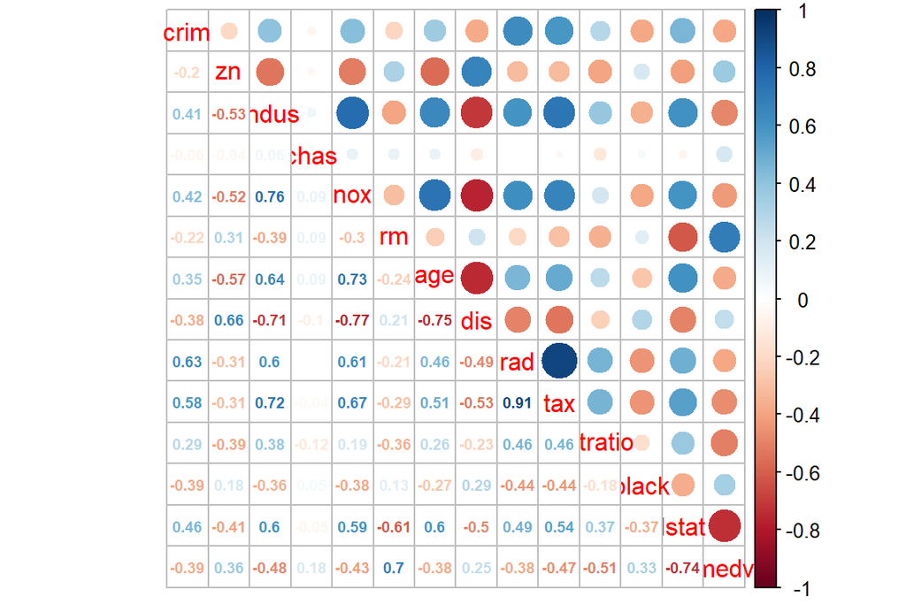

```r
cor_matrix<-cor(Boston)

corrplot.mixed(cor_matrix, number.cex = .6)
```

```r
summary(Boston)
```

```
##       crim                zn             indus            chas
##  Min.   : 0.00632   Min.   :  0.00   Min.   : 0.46   Min.   :0.00000
##  1st Qu.: 0.08204   1st Qu.:  0.00   1st Qu.: 5.19   1st Qu.:0.00000
##  Median : 0.25651   Median :  0.00   Median : 9.69   Median :0.00000
##  Mean   : 3.61352   Mean   : 11.36   Mean   :11.14   Mean   :0.06917
##  3rd Qu.: 3.67708   3rd Qu.: 12.50   3rd Qu.:18.10   3rd Qu.:0.00000
##  Max.   :88.97620   Max.   :100.00   Max.   :27.74   Max.   :1.00000
##       nox               rm             age              dis
##  Min.   :0.3850   Min.   :3.561   Min.   :  2.90   Min.   : 1.130
##  1st Qu.:0.4490   1st Qu.:5.886   1st Qu.: 45.02   1st Qu.: 2.100
##  Median :0.5380   Median :6.208   Median : 77.50   Median : 3.207
##  Mean   :0.5547   Mean   :6.285   Mean   : 68.57   Mean   : 3.795
##  3rd Qu.:0.6240   3rd Qu.:6.623   3rd Qu.: 94.08   3rd Qu.: 5.188
##  Max.   :0.8710   Max.   :8.780   Max.   :100.00   Max.   :12.127
##       rad              tax           ptratio          black
##  Min.   : 1.000   Min.   :187.0   Min.   :12.60   Min.   :  0.32
##  1st Qu.: 4.000   1st Qu.:279.0   1st Qu.:17.40   1st Qu.:375.38
##  Median : 5.000   Median :330.0   Median :19.05   Median :391.44
##  Mean   : 9.549   Mean   :408.2   Mean   :18.46   Mean   :356.67
##  3rd Qu.:24.000   3rd Qu.:666.0   3rd Qu.:20.20   3rd Qu.:396.23
##  Max.   :24.000   Max.   :711.0   Max.   :22.00   Max.   :396.90
##      lstat            medv
##  Min.   : 1.73   Min.   : 5.00
##  1st Qu.: 6.95   1st Qu.:17.02
##  Median :11.36   Median :21.20
##  Mean   :12.65   Mean   :22.53
##  3rd Qu.:16.95   3rd Qu.:25.00
##  Max.   :37.97   Max.   :50.00
```

Corrplot shows the relationships between variables. Highest positive correlations are between rad and tax, indus and nox and age and nox. Highest negative correlations are between age and dis, lstat and med and dis and nox.

When we look at the summaries of variables, we see that their distributions are very different from eachother. This is why next we need to scale them, so we can do linear discriminant analysis later.

## 4) Scaling dataset and wrangling crime variable

```r
boston_scaled <- scale(Boston)

summary(boston_scaled)
```

```
##       crim                 zn               indus
##  Min.   :-0.419367   Min.   :-0.48724   Min.   :-1.5563
##  1st Qu.:-0.410563   1st Qu.:-0.48724   1st Qu.:-0.8668
##  Median :-0.390280   Median :-0.48724   Median :-0.2109
##  Mean   : 0.000000   Mean   : 0.00000   Mean   : 0.0000
##  3rd Qu.: 0.007389   3rd Qu.: 0.04872   3rd Qu.: 1.0150
##  Max.   : 9.924110   Max.   : 3.80047   Max.   : 2.4202
##       chas              nox                rm               age
##  Min.   :-0.2723   Min.   :-1.4644   Min.   :-3.8764   Min.   :-2.3331
##  1st Qu.:-0.2723   1st Qu.:-0.9121   1st Qu.:-0.5681   1st Qu.:-0.8366
##  Median :-0.2723   Median :-0.1441   Median :-0.1084   Median : 0.3171
##  Mean   : 0.0000   Mean   : 0.0000   Mean   : 0.0000   Mean   : 0.0000
##  3rd Qu.:-0.2723   3rd Qu.: 0.5981   3rd Qu.: 0.4823   3rd Qu.: 0.9059
##  Max.   : 3.6648   Max.   : 2.7296   Max.   : 3.5515   Max.   : 1.1164
##       dis               rad               tax             ptratio
##  Min.   :-1.2658   Min.   :-0.9819   Min.   :-1.3127   Min.   :-2.7047
##  1st Qu.:-0.8049   1st Qu.:-0.6373   1st Qu.:-0.7668   1st Qu.:-0.4876
##  Median :-0.2790   Median :-0.5225   Median :-0.4642   Median : 0.2746
##  Mean   : 0.0000   Mean   : 0.0000   Mean   : 0.0000   Mean   : 0.0000
##  3rd Qu.: 0.6617   3rd Qu.: 1.6596   3rd Qu.: 1.5294   3rd Qu.: 0.8058
##  Max.   : 3.9566   Max.   : 1.6596   Max.   : 1.7964   Max.   : 1.6372
##      black             lstat              medv
##  Min.   :-3.9033   Min.   :-1.5296   Min.   :-1.9063
##  1st Qu.: 0.2049   1st Qu.:-0.7986   1st Qu.:-0.5989
##  Median : 0.3808   Median :-0.1811   Median :-0.1449
##  Mean   : 0.0000   Mean   : 0.0000   Mean   : 0.0000
##  3rd Qu.: 0.4332   3rd Qu.: 0.6024   3rd Qu.: 0.2683
##  Max.   : 0.4406   Max.   : 3.5453   Max.   : 2.9865
```

Scaling data makes variables comparable, when every mean is now zero.

```r
# some more data wrangle for variable crime

boston_scaled <- as.data.frame(boston_scaled)

bins <- quantile(boston_scaled$crim)

crime <- cut(boston_scaled$crim, breaks = bins, include.lowest = TRUE, label = c("low", "med_low", "med_high", "high"))

boston_scaled <- dplyr::select(boston_scaled, -crim)

boston_scaled <- data.frame(boston_scaled, crime)

# creating train and test datasets

n <- nrow(boston_scaled)

rows <- sample(n, size = n*0.8)

train <- boston_scaled[rows,]

test <- boston_scaled[-rows,]
```

## 5) Fitting linear discriminant analysis

```r
lda.m <- lda(crime ~ ., data = train)
lda.m
```

```
## Call:
## lda(crime ~ ., data = train)
##
## Prior probabilities of groups:
##       low   med_low  med_high      high
## 0.2277228 0.2400990 0.2673267 0.2648515
##
## Group means:
##                  zn      indus        chas        nox          rm
## low       0.8776043 -0.9569536 -0.10115080 -0.8774288  0.48734928
## med_low  -0.1130598 -0.2766194  0.01179157 -0.5856265 -0.12208458
## med_high -0.3911636  0.2418728  0.23803578  0.4320435  0.07481929
## high     -0.4872402  1.0149946 -0.01476176  1.0700640 -0.44080692
##                 age        dis        rad        tax    ptratio
## low      -0.8440726  0.8456002 -0.7072378 -0.7317327 -0.4825359
## med_low  -0.3792669  0.3772235 -0.5544520 -0.4706971 -0.1423181
## med_high  0.4442686 -0.4253312 -0.4023207 -0.2747286 -0.2955238
## high      0.8117676 -0.8596836  1.6596029  1.5294129  0.8057784
##                black        lstat         medv
## low       0.37052171 -0.769724527  0.567264829
## med_low   0.31577966 -0.140983883 -0.006481437
## med_high  0.09884684  0.008751124  0.159326437
## high     -0.82146286  0.860551965 -0.672713049
##
## Coefficients of linear discriminants:
##                  LD1         LD2         LD3
## zn       0.168522272  0.59676903 -1.07681783
## indus    0.005909241 -0.38077794  0.53582641
## chas    -0.086309596 -0.02231309  0.09626836
## nox      0.331743326 -0.78140015 -1.33011188
## rm      -0.119535821 -0.04561918 -0.09195438
## age      0.346414774 -0.27441383 -0.22802231
## dis     -0.131148948 -0.11255809  0.24139235
## rad      3.336924308  0.74792077  0.12800119
## tax     -0.156119383  0.26583146  0.35811415
## ptratio  0.178578859  0.04551063 -0.48714290
## black   -0.166838602 -0.01580653  0.11858796
## lstat    0.141556154 -0.13225034  0.33863823
## medv     0.164872063 -0.28876492 -0.26334689
##
## Proportion of trace:
##    LD1    LD2    LD3
## 0.9497 0.0370 0.0133
```

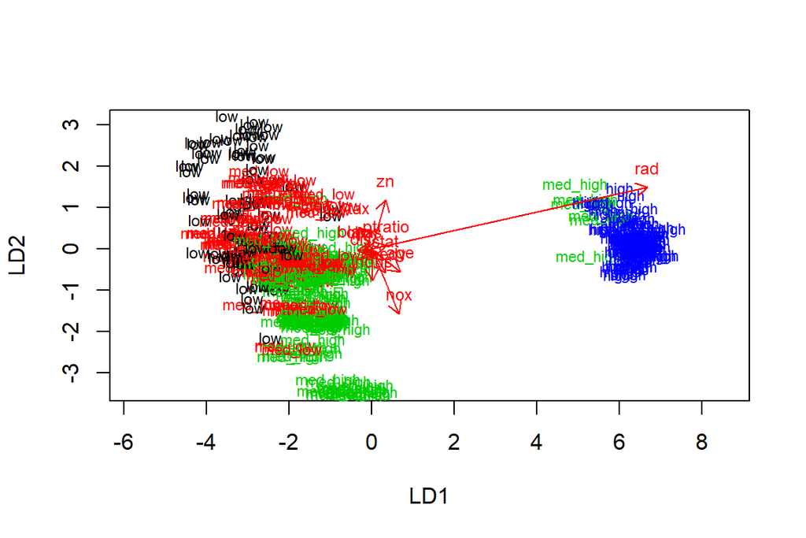

```r
# and plotting
# arrows

lda.arrows <- function(x, myscale = 1, arrow_heads = 0.1, color = "red", tex = 0.75, choices = c(1,2)){
  heads <- coef(x)
  arrows(x0 = 0, y0 = 0,
         x1 = myscale * heads[,choices[1]],
         y1 = myscale * heads[,choices[2]], col=color, length = arrow_heads)
  text(myscale * heads[,choices], labels = row.names(heads),
       cex = tex, col=color, pos=3)
}

classes <- as.numeric(train$crime)

plot(lda.m, dimen = 2, col = classes, pch = classes)
lda.arrows(lda.m, myscale = 2)
```

Most clear class seems to be high crime rate. Med_high and med_low classes seem to blend within eachother and low class is also really spread. The variables with biggest effects (longest arrows) are rad, zn and nox.

## 6) Prediction based on the fitted model

```r
correct_classes <- test$crime

test <- dplyr::select(test, -crime)

lda.pre <- predict(lda.m, newdata = test)

table(correct = correct_classes, predictions = lda.pre$class)
```

```
##           predictions
## correct    low med_low med_high high
##   low       22      10        3    0
##   med_low    4      15       10    0
##   med_high   2       3       13    0
##   high       0       0        1   19
```

The cross table shows that high values were predicted correctly. In other classes there are more errors, which was also implied from the plot above. This means that training data didnt succeed that well with our model, or that maybe we should think about defining the classes again.